# In Class Activity - Raster Data

Rasters are spatial continuous distributions of geospatial data. We have been shown that we an work with data in raster format using either `terra` and working on object directly, or via `dplyr` and using the normal data manipulation routines that we’ve learned for non-spatial data. In this *in class* exercise, you may use both of these techniques to load, manipulate, and display geospatial data.

## The Raw Data

The data for this will be the same Baja California data we showed in the lectures on [points](https://dyerlabteaching.github.io/Spatial-Points/slides.html) and [rasters](https://dyerlabteaching.github.io/Raster-Data/slides.html).

```r
raster_url <- "https://dyerlabteaching.github.io/CourseData/Spatial/alt_22.tif"
beetle_url <- "https://dyerlabteaching.github.io/CourseData/Spatial/AraptusDispersalBias.csv"
```

## The Questions

1. Load the raster and point data in and crop to an appropriate size to display the locations of the sampling plots and make a label for each site.

```r
library( tidyverse )
library( terra )
library( tidyterra )
library( sf )
elev <- rast( raster_url )

read_csv( beetle_url )  |>
  st_as_sf( coords = c("Longitude","Latitude"),
            crs = 4326 ) -> beetles
beetles
```

```
Simple feature collection with 31 features and 7 fields
Geometry type: POINT
Dimension:     XY
Bounding box:  xmin: -114.2935 ymin: 23.2855 xmax: -109.327 ymax: 29.32541
Geodetic CRS:  WGS 84
# A tibble: 31 × 8
   Site  Males Females Suitability MFRatio GenVarArapat GenVarEuphli
 * <chr> <dbl>   <dbl>       <dbl>   <dbl>        <dbl>        <dbl>
 1 32       40      27      0.0563   1.48         0.144       0.219
 2 73       11       5      0.146    2.2          0.137       0.253
 3 93       25      21      0.163    1.19         0.163       0.133
 4 const    18      11      0.174    1.64         0.280       0.235
 5 159      22      15      0.188    1.47         0.160       0.0809
 6 88       23      18      0.219    1.28         0.266       0.176
 7 177      49      50      0.262    0.98         0.338       0.05
 8 166      19      26      0.267    0.731        0.120       0.286
 9 161      64      63      0.279    1.02         0.252       0.171
10 64       16      19      0.288    0.842        0.141       0.251
# ℹ 21 more rows
# ℹ 1 more variable: geometry <POINT [°]>
```

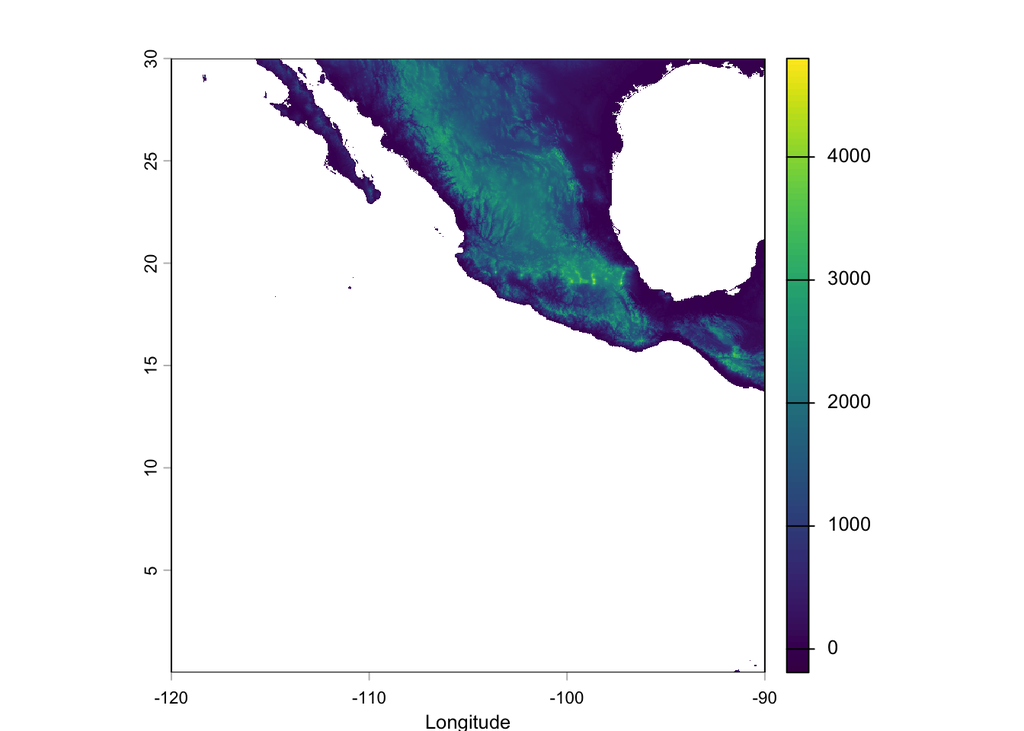

```r
plot( elev, xlab="Longitude" )
```

```r
beetles |>
  st_union() |>
  st_buffer( dist = 1 ) |>
  st_bbox()
```

```
      xmin       ymin       xmax       ymax
-114.29354   23.28549 -109.32699   29.32542
```

```r
baja_extent <- ext( c(-115.29354,-108,22,30))

baja_elev <- crop( elev, baja_extent )
baja_elev
```

```
class       : SpatRaster
size        : 960, 875, 1  (nrow, ncol, nlyr)
resolution  : 0.008333333, 0.008333333  (x, y)
extent      : -115.2917, -108, 22, 30  (xmin, xmax, ymin, ymax)
coord. ref. : lon/lat WGS 84 (EPSG:4326)
source(s)   : memory
varname     : alt_22
name        : alt_22
min value   :   -202
max value   :   2774
```

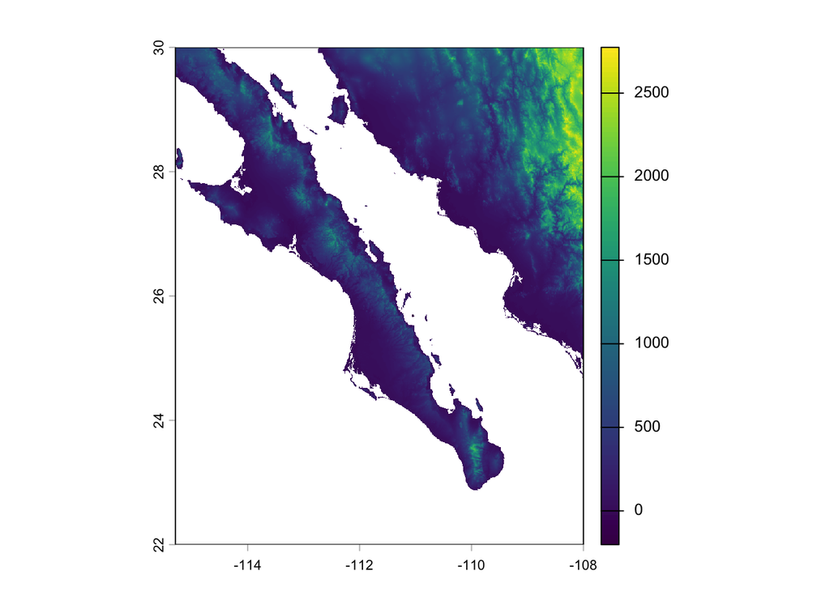

```r
plot( baja_elev)
```

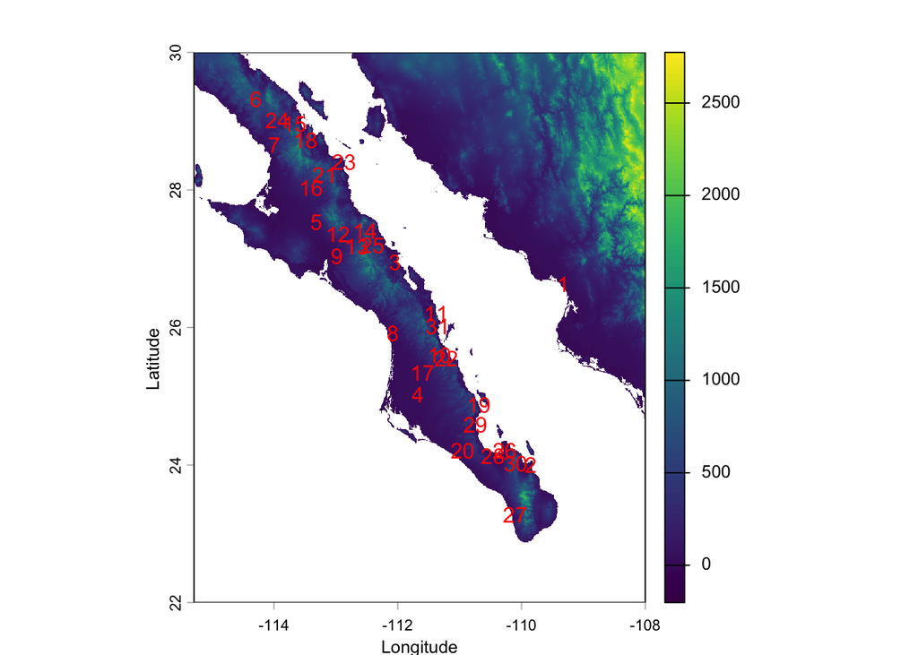

```r
plot( baja_elev, xlab="Longitude", ylab="Latitude")
text( beetles,  pch=16, col="red" )
```

```
<SpatRaster> resampled to 500916 cells.
```

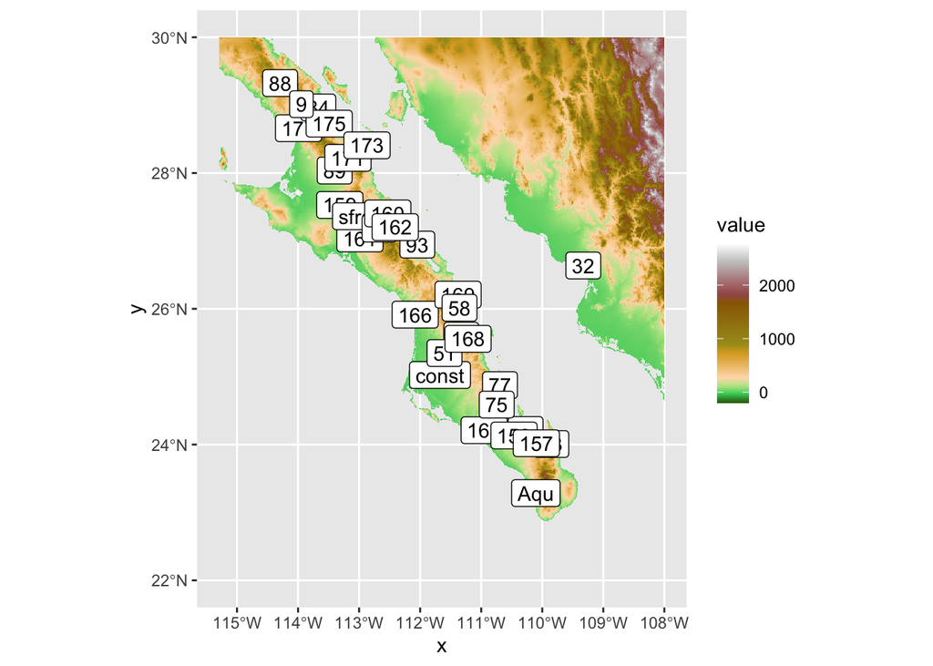

```r
library( ggrepel )
ggplot() +
  geom_spatraster( data = baja_elev ) +
  scale_fill_hypso_c( na.value = NA ) +
  geom_sf_label( aes(label=Site),
                 data = beetles)
```

2. Use the `click()` function to crop the raster and filter the sites to include only the region that is on the peninsula of Baja California. Plot the raster and sites as labels.
3. The peninsula of Baja California is divided into the States of *Baja California Norte* and *Baja California Sur*. The border between these states is at 28° Latitude. Divide the sample locations into groups based upon which state they are located and plot the average sex ratio of the sample sites partitioned by each site.
4. Is there a relationship between the observed sex ratio and the elevation at that site?